# Data Storytelling

Data Storytelling is is like a quest. The story is right here, hidden inside the correlated features of our dataset and it is our job to find it.

[figure not shown]

Falling stars at night (source: [link](https://www.pexels.com/photo/falling-stars-at-night-48198/))

So what story [this](https://www.kaggle.com/nasa/meteorite-landings) dataset of over 45k meteorites that have struck Earth can tell us ? One thing for sure is that it cannot be meteorrible (terrible)..

## Import

As always, we first start with our libraries import

```python
import pandas as pd
import numpy as np
import matplotlib.pyplot as plt
import seaborn as sns
from tqdm import tqdm
import math
import geopandas as gpd
```

```python
ds = pd.read_csv("datasets/meteorite-landings.csv")
```

## Introduction

Now that our dataset is imported in a Pandas DataFrame, we will explore its content in order to extract some more insights about Meteorite Landings.

```python
len(ds['id'].unique())
```

```
45716
```

```python
ds.head()
```

|  | name | id | nametype | recclass | mass | fall | year | reclat | reclong | GeoLocation |
| --- | --- | --- | --- | --- | --- | --- | --- | --- | --- | --- |
| 0 | Aachen | 1 | Valid | L5 | 21.0 | Fell | 1880.0 | 50.77500 | 6.08333 | (50.775000, 6.083330) |
| 1 | Aarhus | 2 | Valid | H6 | 720.0 | Fell | 1951.0 | 56.18333 | 10.23333 | (56.183330, 10.233330) |
| 2 | Abee | 6 | Valid | EH4 | 107000.0 | Fell | 1952.0 | 54.21667 | -113.00000 | (54.216670, -113.000000) |
| 3 | Acapulco | 10 | Valid | Acapulcoite | 1914.0 | Fell | 1976.0 | 16.88333 | -99.90000 | (16.883330, -99.900000) |
| 4 | Achiras | 370 | Valid | L6 | 780.0 | Fell | 1902.0 | -33.16667 | -64.95000 | (-33.166670, -64.950000) |

Looking at our dataset, we have 10 columns. Each of these columns are explained to contain the following information:

- **name**: the name of the meteorite (sometimes just its location, modified with numeric data or composition)
- **id**: a unique identifier of each meteorite
- **nametype**: one of:
  - *valid*: a typical meteorite
  - *relict*: a meteorite that has been highly degraded by weather on Earth
- **recclass**: the class of the meteorite (meteorite classification is a vast field of study that you can learn more about in [this wikipedia article](https://en.wikipedia.org/wiki/Meteorite_classification))
- **mass**: the mass of the meteorite, in grams
- **fall**: one of:
  - *Fell*: the meteorite's fall was observed
  - *Found*: the meteorite's fall was **not** observed
- **year**: the year the meteorite fell, or the year it was found (linked with the "*fall*" column)
- **reclat**: the latitude of the meteorite's landing
- **reclong**: the longitude of the meteorite's landing
- **GeoLocation**: a parentheses-enclose, comma-separated tuple that combines reclat and reclong

As we can see, our categorical columns could be the bearing points for a more exhaustive search on what properties could be typical for each category of meteorite, especially when differentiating *fallen* from *found* meteorites.

We will use this analysis to answer the following question: "*Is there any geographical distribution difference between the observed falls and the found meteorite, and do they have different properties?*".

To answer this, we will first introduce each columns independently, giving insights on their values and properties. Then, we will focus on answering the question by drawing the good visuals for this problematic. Then we will draw our conclusion.

## Features Analysis

As explained before, each line of our dataset is made of 10 columns. We will analyze and give insights on each and every single one of them.

A first distinction we could make in those features is about how they describe the meteorite. Indeed, some columns seem to go along describing the positio where the meteorite fell whereas others describe more its physical properties. We could then group them as followed:

| Localisation | Physical properties | Others |
| --- | --- | --- |
| name | nametype | id |
| reclat | recclass | fall |
| reclong | mass | year |
| GeoLocation |  |  |

Therefore, we should see some sort of redundancy between features, especially the ones targeting the localisation.

### "Localisation" feature

#### Name

```python
ds_name = ds["name"]
```

```python
print("There are {} unique names out of {} total with {} NaN values".format(len(ds_name.unique()), len(ds_name), len(ds_name[ds_name.isna()])))
```

```
There are 45716 unique names out of 45716 total with 0 NaN values
```

There does not seem to be any redundant name. However, as explained in the description of the data, some names may have numbers in them. Maybe we could then have the identical names but followed by differents numbers. To make sure of that let's first check if there is any name with numbers inside:

```python
ds_name_with_numeric = ds_name[ds_name.str.contains("[0-9]", regex=True)]
print("There exist {} meteorites with numeric names. It represents {}% of our dataset.\nWe can display the following ones as example:".format(len(ds_name_with_numeric), 100*round(len(ds_name_with_numeric)/len(ds_name), 2)))
ds_name_with_numeric.head()
```

```
There exist 42471 meteorites with numeric names. It represents 93.0% of our dataset.
We can display the following ones as example:
```

```
37     Northwest Africa 5815
137          Boumdeid (2003)
138          Boumdeid (2011)
480            Kijima (1906)
634             Modoc (1905)
Name: name, dtype: object
```

As we can now see, the vast majority of our dataset has numeric values in it. Therefore, our original process would have higher difficulties of finding redundancy in the names of our meteorite. To fix this, we will recreate a new Pandas Series where the string characters are limited to the latin alphabet.

```python
def remove_non_alpha(string):
    return "".join(char for char in string if char.isalpha())

ds_name_fixed = ds_name.apply(remove_non_alpha)
#To make sure we don't have problem with casing, we put all strings to lower
ds_name_fixed = ds_name_fixed.str.lower()
```

```python
print("Once deprived from non-alphabetical characteres, there are {} unique names out of {} total".format(len(ds_name_fixed.unique()), len(ds_name_fixed)))
```

```
Once deprived from non-alphabetical characteres, there are 3475 unique names out of 45716 total
```

This small amount of unique values is very beneficial for us as we could easily draw an histogram of the values and analyse its distribution. Let's, for example draw an histogram of the 20 most common meteorite names:

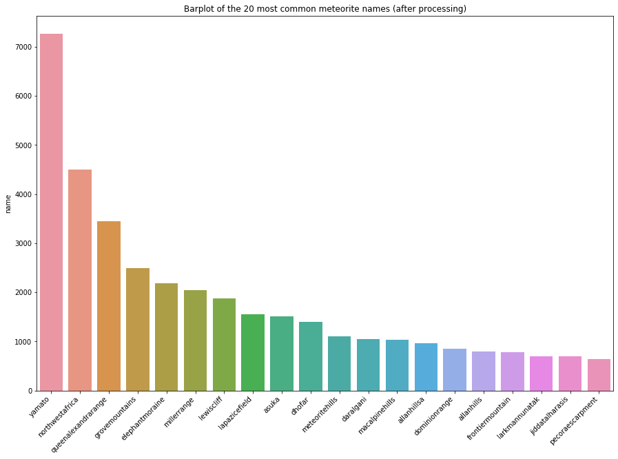

```python
# Setting the size of
plt.rcParams['figure.figsize'] = [15, 10]

twenty_most_common_names = ds_name_fixed.value_counts()[:20]
common_names_barplot = sns.barplot(twenty_most_common_names.keys(), twenty_most_common_names);
common_names_barplot.set_xticklabels(common_names_barplot.get_xticklabels(), rotation=45, horizontalalignment='right')
common_names_barplot.set_title("Barplot of the 20 most common meteorite names (after processing)")
common_names_barplot;
```

Then it appears clearly that the most common place of meteorite landings is called "*Yamato*". After research, it appears that this name is a reference to the Yamato Glacier which is a glacier about 6 miles (10 km) wide, flowing west between Mount Fukushima and Mount Eyskens in the Queen Fabiola Mountains of Antarctica (source: [link](https://en.wikipedia.org/wiki/Yamato_Glacier)).

Interestingly, other names also make reference to places in **Antarctica** such as "*Queen Alexandra Range*" which is a Mountain range that have multiple peaks more than 4000m high (source: [link](https://www.peakbagger.com/range.aspx?rid=8122)).

Therefore, it seems interesting to point this area as, potentially, receiving a lot of meteorites.

#### GeoLocation (Reclat, Reclong)

GeoLocation is, as explained in the introduction's summary, just a tuple combining **reclat** and **reclong** which stand for, respectively, *Recorded Latitude* and *Recorded Longitude*. They give the position of the meteorite landing. Somewhat important to precisely localize the meteorite, satellite location may not have always been recorded precisely.

```python
ds_geo = ds["GeoLocation"]
```

```python
print("There are {} unique location out of {} total as well as {} NaN values".format(len(ds_geo.unique()), len(ds_geo), len(ds_geo[ds_geo.isna()])))
```

```
There are 17101 unique location out of 45716 total as well as 7315 NaN values
```

This surprising result raises multiple questions:

1. What are the most frequent locations if they are not all unique ?
2. Is the NaN class the most frequent one ?
3. Is the non-NaN values always coherent ?

All these problemes comes from awareness that have been raised by the strange former counting result of this "*GeoLocation*" column.

*What are the most frequent (exact) locations ?*

> Two meteorites should not have been registered at the same coordinate if they are differents. This could be a hint that a group of meteorite being discovered close one to another has being registered as a list of multiple meteorites with all the same location. Therefore, this raises doubts on coherence of the location Data.

To analyze this, let's see the most frequent locations and try to explain them.

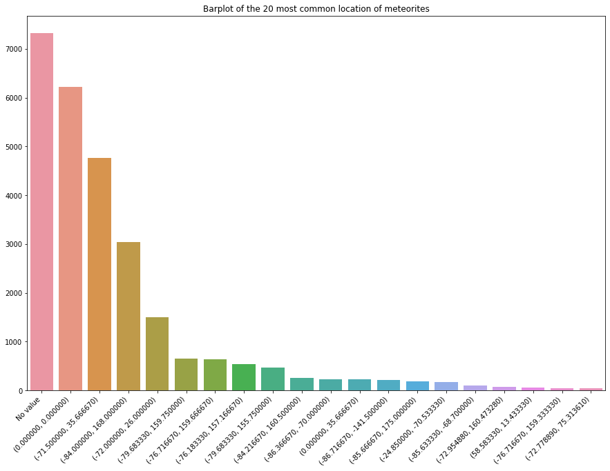

```python
twenty_most_common_locations = ds_geo.value_counts()[:19]
#Adding the NaN counts
twenty_most_common_locations = twenty_most_common_locations.append(pd.Series(len(ds_geo[ds_geo.isna()]), index=["No value"]))
twenty_most_common_locations = twenty_most_common_locations.sort_values(ascending=False)

common_location_barplot = sns.barplot(twenty_most_common_locations.keys(), twenty_most_common_locations);
common_location_barplot.set_xticklabels(common_location_barplot.get_xticklabels(), rotation=45, horizontalalignment='right')
common_location_barplot.set_title("Barplot of the 20 most common location of meteorites")
common_location_barplot;
```

As we can see here, the bigger class has no value at all (NaN). However, the second class should be treated as the same, considering that de value of (0.0, 0.0) is meaningless.

Therefore, our first location with real data is *(-71.5, 35.666670)* which is, again, in **Antarctica**.

```python
meteorite_landing =[-71.5, 35.666670]

m = folium.Map(
    center=meteorite_landing,
    zoom_start=6)

folium.Marker(location=meteorite_landing, draggable=False).add_to(m)

m
```

[output not shown]

We have displayed here the position of our most common class of fallen meteorites that looks to be lost in the middle of Antarctica. But what about the other most common classes ?

```python
gdf = gpd.GeoDataFrame(
    ds, geometry=gpd.points_from_xy(ds.reclong, ds.reclat))
```

```python
import folium
```

```python
m2 = folium.Map(
    #layers=(basemap_to_tiles(basemaps.NASAGIBS.ModisTerraTrueColorCR, "2017-04-08"), ),
    zoom_start=2,
    no_touch=True)

for key in twenty_most_common_locations.keys():
    try:
        pos = eval(key)
        #print("Position: {}".format(pos))
        folium.Marker(pos).add_to(m2)
    except:
        print("Invalid position")

m2
```

```
Invalid position
```

[interactive chart not shown]

As we can easily see now, the vast majority of meteorite landigs happen to be in Antarctica, according to this dataset. But what kind of meteorite do we find the most ?

To know that, we will dive more into the physical properties of our recorded meteorites.

### "Physical properties" feature

We have pointed out, for the moment, that most meteorites seem to be located in Antarctica (or at least the ones we find). We will now explore in more details what comes to meteorites composition and properties. After this, we will eventually link our result and do some multifeature analysis in order to answer our problematic.

#### nametype

As a reminder, nametype column can take two values; one of:

- *valid*: a typical meteorite
- *relict*: a meteorite that has been highly degraded by weather on Earth

What are the distribution of each feature ? How could we interpret this ? To start, let's just have a barplot (circle plot are not convenient at all to notice small differences, this is why barplot is always to be considered instead of circle plot).

```
45641 of 'Valid' values out of 45716 total
```

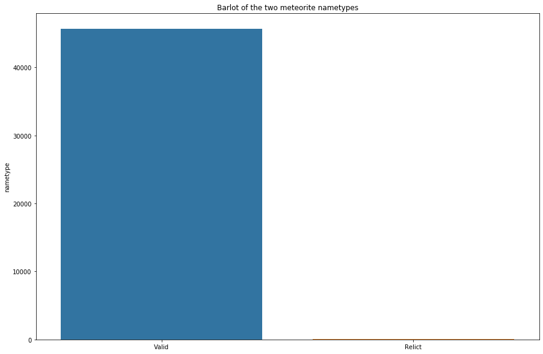

```python
ds_nametype = ds["nametype"]
ds_nametype_val_counts = ds_nametype.value_counts()
print("{} of 'Valid' values out of {} total".format(ds_nametype_val_counts["Valid"], len(ds_nametype)))
nametype_barplot = sns.barplot(ds_nametype_val_counts.keys(), ds_nametype_val_counts)
nametype_barplot.set_title("Barlot of the two meteorite nametypes")
nametype_barplot;
```

It's pretty fair to say that only a very small amount (75) of meteorites have been degraded by weather on Earth. In the following parts, we will try to see if there is any drawable conclusion from this.

#### recclass

This column describes the class of the meteorite. Meteorite classification is very precise with more than 35 different classes. However, 3 main categories have to be pointed out :

- Stony meteorites
- Stony-iron meteorites
- Iron meteorites

Each of them are then subdivided in smaller, more precise categories.

| **Stony Meteorites** | Chondrites | Carbonaceous chondrite | CI CM-CO CV-CK CR |
| --- | --- | --- | --- |
|  |  | Ordinary chondrite | H L LL |
|  |  | Enstatite chondrite | EH EL |
|  |  | Other chondrite | R K |
|  | Achondrites | Primitive achondrites | Acapulcoite Lodranite Winonaite |
|  |  | Asteroidal achondrites | HED Angrite Aubrite Ureilite Brachinite |
|  |  | Lunar meteorite |  |
|  |  | Martian meteorite | Shergottites Nakhlites Chassignites Others (e.g ALH84001) |
| **Stony-iron Meteorites** | Pallasites | Main group |  |
|  |  | Eagle station |  |
|  |  | Pyroxene |  |
|  | Mesosiderite |  |  |
| **Iron Meteorites** | Magmatic |  | IC IIAB IIC IID IIF IIG IIIAB IIIE IIIF IVA IVB |
|  | "Non magmatic" |  | IAB sLL sLM sLH sHL sHH IIE IIICD |

These are the categories we could find in the *recclass* column of our meteorite dataset.

```python
ds_recclass = ds['recclass']
ds_recclass.head()
```

```
0             L5
1             H6
2            EH4
3    Acapulcoite
4             L6
Name: recclass, dtype: object
```

As we can see here, the classes of meteorite we have are the more precise group. Before analyzing them this way, it could be thoughtful to first use the 3 way division between Stony, Stony-iron and Iron meteorites. For that intent, let's create a Python dictionnary listing all subclasses of each group.

```python
main_meteorite_classes = {
    "stony": ["CI", "CM", "CO", "CV", "CK", "CR", "CH", "CB", "H", "L", "LL", "E", "OC", "LLL", "HL", "EH", "EL", "R", "K", "ACAPULCOITE", "LODRANITE", "WINONAITE", "HOWARDITE", "EUCRITE", "DIOGENITE", "ANGRITE", "AUBRITE", "UREILITE", "BRACHINITE", "LUNAR", "SHERGOTTITE", "NAKHLITE", "CHASSIGNITE", "MARTIAN", "ACHONDRITE", "CHONDRITE", "RELICTOC"],
    "stony_iron": ["PALLASITE", "MESOSIDERITE"],
    "iron": ["IC", "IIAB", "IIC", "IID", "IIF", "IIG", "IIIAB", "IIIE", "IIIF", "IVA", "IVB", "IAB", "UDEI", "PITTS", "sLL", "sLM", "sLH", "sHL", "sHH", "IIE"]
}

def get_category(recclass):
    #to make sure the matching works correctly, we remove any non alpha character
    corrected_recclass = "".join(char for char in recclass if char.isalpha())

    #some recclass also contains Iron in their name, if it is so, we directly categorise them.
    if "iron" in corrected_recclass.lower():
        return "iron"

    #we loop over the meteorite classes to know if, by any chance, the meteorite is indeed in this class
    for key in main_meteorite_classes.keys():

        # we check if the exact recclass of the meteorite is in one of the three arrays. If yes, e return the according key (stony, stony_iron or iron)
        if (corrected_recclass.upper() in main_meteorite_classes[key]):
            return key

        # some names are composed of the class and the main category or other strings. Therefore, we loop other each key's array and
        #check if any name of size more than 3 is inside the recclass of the meteorite (ex: "Pallasite" is in "PallasitePMG" )
        for name in main_meteorite_classes[key]:
            if (len(name) >= 3 and name in corrected_recclass.upper()):
                return key

    #print("Unclassified: {}".format(corrected_recclass))
    return "unclassified"
```

Now that we have defined our method used to translate a precise category in one of the main three one, we will create a new column in our dataframe.

```python
ds_recclass_as_df = ds_recclass.to_frame()
ds_recclass_as_df["main_category"] = ds_recclass_as_df["recclass"].apply(get_category)
ds_main_category = ds_recclass_as_df["main_category"]
```

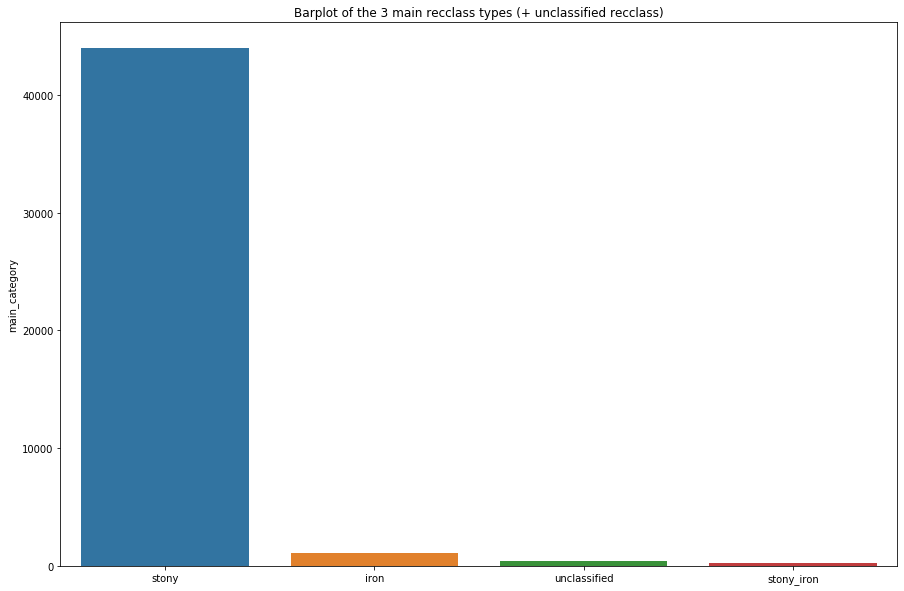

```python
counted_categories = ds_main_category.value_counts()

main_category_barplot = sns.barplot(counted_categories.keys(), counted_categories)
main_category_barplot.set_xticklabels(main_category_barplot.get_xticklabels())
main_category_barplot.set_title("Barplot of the 3 main recclass types (+ unclassified recclass)")
main_category_barplot;
```

As we can see here, most of our stones are of the "*Stony*" kind. However, there are still a couple of misclassified stones under the "*Other*" category. Let's check them out to see what they are like.

Most common unclassified stones are:

```python
ds_unclassified_recclass = ds_recclass_as_df[ds_recclass_as_df["main_category"] == "unclassified"]

twenty_most_common_unclassified_recclass = ds_unclassified_recclass["recclass"].value_counts()[:20]

twenty_most_common_unclassified_recclass_as_df = twenty_most_common_unclassified_recclass.to_frame()
twenty_most_common_unclassified_recclass_as_df["recclass_count"] = twenty_most_common_unclassified_recclass_as_df["recclass"]
twenty_most_common_unclassified_recclass_as_df["recclass"] = twenty_most_common_unclassified_recclass_as_df.index
```

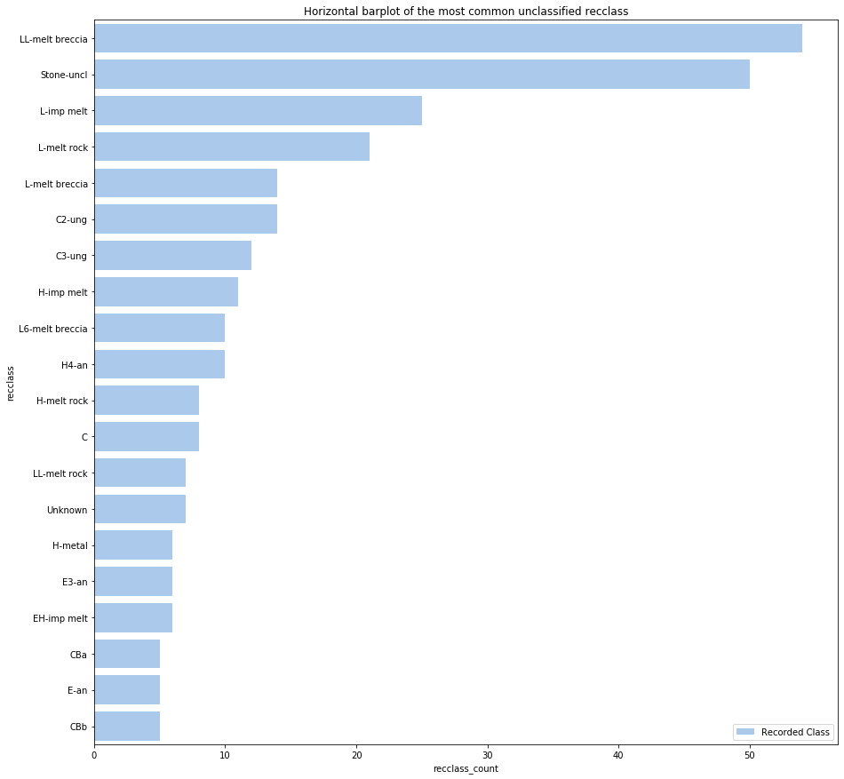

```python
f, ax = plt.subplots(figsize=(15, 15))

sns.set_color_codes("pastel")
common_unclassified_recclass_barplot = sns.barplot(
    x="recclass_count", y="recclass", label="Recorded Class", data=twenty_most_common_unclassified_recclass_as_df, color="b")

# Add a legend and informative axis label
ax.legend(ncol=2, loc="lower right", frameon=True)

common_unclassified_recclass_barplot.set_title("Horizontal barplot of the most common unclassified recclass")
common_unclassified_recclass_barplot;
```

One important class to notice is "**Stone-uncl**" which literally means "*Unclassified stone*". These rocks are meteorites that are yet to have been classified between the already 3 existing class. It could be interesting to focus on them in further analysis to try to draw conclusion on what they are and if we can get a specific pattern to explain why they are unclassified.

#### mass

This column relates to the mass of the given meteorite. This mass is in grams. We could think that the heaviest the meteorite is, the most likely it is to have been observed. First, let's observe the mass distribution using an histogram. As ds_mass is a numeric column, there might be some "*NaN*" values laying out in the column. It would seem logical to find some as not all meteorite ever found could have been weighted or at least that their weight was registered.

```python
ds_mass = ds['mass']
print("{} out of {} total values are NaN".format(len(ds_mass[ds_mass.isnull()]), len(ds_mass)))
```

```
131 out of 45716 total values are NaN
```

This small amount of values will and should not impact our analysis of the mass column, so we will not care about them. However, it could be interesting to analyze more in details what are the characteristics of NaN masses.

```python
ds_mass_corrected = ds_mass.dropna()
print("Series still contains NaN values? {} (should be False)".format(ds_mass_corrected.isnull().values.any()))
```

```
Series still contains NaN values? False (should be False)
```

```python
ds_mass_corrected.describe()
```

```
count    4.558500e+04
mean     1.327808e+04
std      5.749889e+05
min      0.000000e+00
25%      7.200000e+00
50%      3.260000e+01
75%      2.026000e+02
max      6.000000e+07
Name: mass, dtype: float64
```

All these observations demonstrate a **highly positively skewed** dataset, meaning that a lot of meteorites have a low weight (half of them under 32.6gr) but a few are extremely massive (60 tons !). To better observe this, we will split the data in two parts:

- The first 50%
- The second 50%

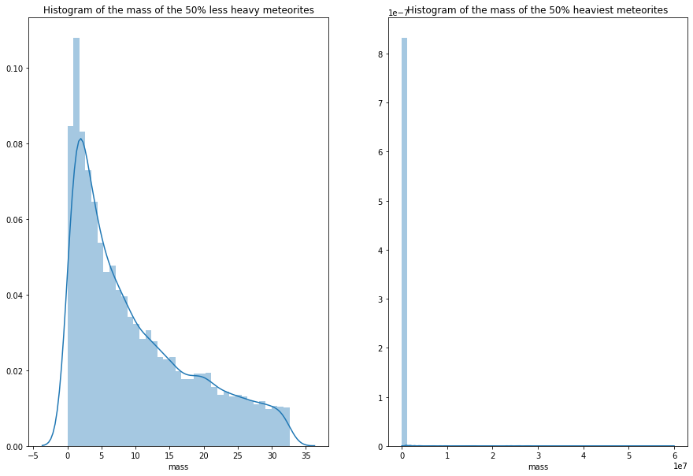

```python
median = ds_mass_corrected.median()

ds_mass_corrected_under = ds_mass_corrected[ds_mass_corrected < median]
ds_mass_corrected_over = ds_mass_corrected[ds_mass_corrected >= median]

fig, (ax_under, ax_over) = plt.subplots(1, 2)

sns.distplot(ds_mass_corrected_under, ax=ax_under).set_title("Histogram of the mass of the 50% less heavy meteorites")
sns.distplot(ds_mass_corrected_over, ax=ax_over).set_title("Histogram of the mass of the 50% heaviest meteorites")
fig;
```

As we can here see, despite using the 50% heaviest meteorites, we still find ourselves with an unintelligible plot. There seem to just be too many differences between outliers. To make this plot more understandable, we will try to remove the outliers.

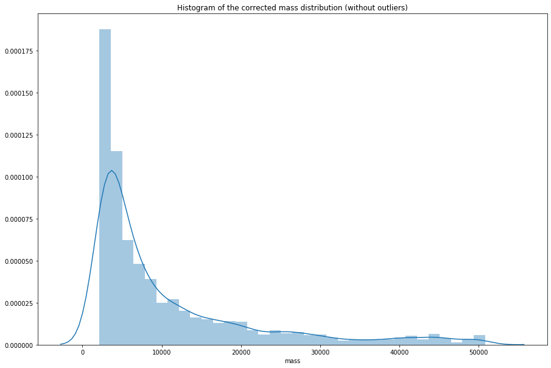

```python
from scipy import stats

stats.zscore(ds_mass_corrected_over)
d = ds_mass_corrected_over[(np.abs(stats.zscore(ds_mass_corrected_over)) < 0.03)]
mass_corrected_plot = sns.distplot(d)
mass_corrected_plot.set_title("Histogram of the corrected mass distribution (without outliers)")
mass_corrected_plot;
```

We can here see that the same positively skewed type of data appear with our plot. This is a sign that the overall dataset mainly consists in, as said earlier, of very lightly weighted meteorites.

### "Other" features

#### fall

This categorical feature is highly useful and is the main point of interest of this dataset: it specifies wether or not a meteorite has been seen falling. I takes two values:

- *Fell*: the meteorite's fall was observed
- *Found*: the meteorite's fall was **not** observed

Let's explore how both are distributed:

```
There are 1107 observed falls for 45716 total. It is roughly 1 meteorite observed for every 41.0 found.
```

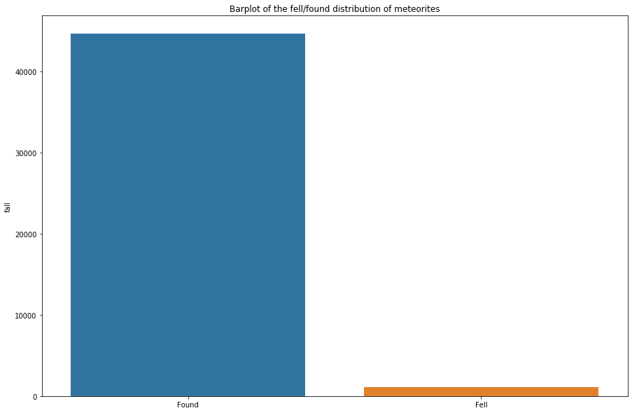

```python
ds_fall = ds["fall"]

fell_found_count = ds_fall.value_counts()

fell_found_barplot = sns.barplot(fell_found_count.keys(), fell_found_count)

print("There are {} observed falls for {} total. It is roughly 1 meteorite observed for every {} found."
      .format(fell_found_count["Fell"], len(ds), round(len(ds)/fell_found_count["Fell"]))
     )

fell_found_barplot.set_title("Barplot of the fell/found distribution of meteorites")
fell_found_barplot;
```

As we could have expected, a lot more meteorites have only been found but not seen falling. This could depend on a lot of factors, including all the other features (e.g, Antarctica is not very populated so less people could see a meteorite falling, making the location a great factor of this). Finding what this feature depends on will be one of our next objective.

#### year

The year indicates the year that the meteorite has been found. There might exist some NaN values as well as for the mass, we will first look out for them and then, we'll see how it looks like on an histogram.

```python
ds_year = ds["year"]
print("{} out of {} total values are NaN".format(len(ds_year[ds_year.isnull()]), len(ds_year)))
```

```
288 out of 45716 total values are NaN
```

So few values will also be negligible in our case. We will therefore just remove them.

```python
ds_year_corrected = ds_year.dropna()
print("Min year: {}\nMax year: {}\nMed year: {}".format(ds_year_corrected.min(), ds_year_corrected.max(), ds_year_corrected.median()))
```

```
Min year: 301.0
Max year: 2501.0
Med year: 1998.0
```

Meteorites finding are as ancient as 301 AC, and the median year is right before the 21st century. However, our maximum year is surprising as it is a data that has not yeat been reached... Let's plot an histogram of the years and we will figure out after about this impossible date.

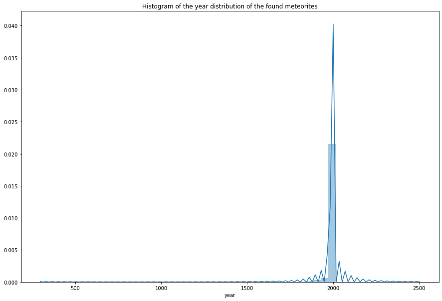

```python
hist_year = sns.distplot(ds_year_corrected)
hist_year.set_title("Histogram of the year distribution of the found meteorites")
hist_year;
```

As we can see here, and as we could have guessed, most of our meteorites have been found around the year 2000. However, we have some weird results. Parts of data seem to have future dates and not only 2501.. Let's dive more into these meteorites found after our current year.

```python
future_discoveries = ds_year_corrected[ds_year_corrected > 2019]
future_discoveries
```

```
30679    2101.0
38188    2501.0
Name: year, dtype: float64
```

Two meteorites seems to come straight from the future. Let's go back to the original dataset to try to find out what this all is about..

```python
future_discoveries_rows = ds[ds_year.notnull().any() and ds_year > 2019]
future_discoveries_rows
```

|  | name | id | nametype | recclass | mass | fall | year | reclat | reclong | GeoLocation | geometry |
| --- | --- | --- | --- | --- | --- | --- | --- | --- | --- | --- | --- |
| 30679 | Northwest Africa 7701 | 57150 | Valid | CK6 | 55.0 | Found | 2101.0 | 0.0 | 0.00000 | (0.000000, 0.000000) | POINT (0.00000 0.00000) |
| 38188 | Ur | 24125 | Valid | Iron | NaN | Found | 2501.0 | 30.9 | 46.01667 | (30.900000, 46.016670) | POINT (46.01667 30.90000) |

We obtain here the two following results. However, meteorite classification is a very serious and almost flawless process. Every meteorite registered in our dataset should exist or any entry should at least have sense. Let's explore this more in details by analyzing each case with the help of an external source: [the Meteoritical Society (TMS) DataBase](https://www.lpi.usra.edu/meteor/metbull.php)

**1. "Northwest Africa 7701" meteorite**

This meteorite seems very legitimate as it contians a name following the usual pattern of " " and it also contains a class as well as a mass.

When searching for it in the TMS DB, the following entry appeared:

[figure not shown]

As we can see, both recclass and mass columns are matching. Also, it is clear that now have a plausible year. "*2010*" being 'close' character-wise to 2101, we could think of a human mistake when completing this dataset. Further details about the meteorite explain it was discovered in Agadir, Morocco. You can find more info about it here.

**2. "Ur" meteorite**

This meteorite has one of the most important information out of all the columns being its found location. When plotted, we obtain this:

```python
mystery_meteorite_landing = [30.900000, 46.016670]

m = folium.Map(
    location = mystery_meteorite_landing,
    zoom_start=12,
    tiles='Stamen Terrain'
)


folium.Marker(mystery_meteorite_landing, popup='<i>"Ur"</i> meteorite').add_to(m)

m
```

[interactive chart not shown]

This meteorite seems to be lost in the middle of Iraq, without a lot of cities around. We just can see the Imam Ali Air Base.. When we search for it in the TMS DB, we obtain the following result:

[figure not shown]

This entry, corroborating our original meteorite location, enlightens the 2501 year of discovery: it was supposed to be a negative value, being -2500 BC. More details about this meteorite can be found here.

Now that we have described every feature on its own, let's create a tiny summary before starting multifeature analysis to try to draw better conclusion about meteorites on Earth.

Feature name

Feature description

name

geolocation

nametype

- 45641 "valid" for only 75 "relict" (that have been damaged by Earth's weather)

recclass

- 3 main classes (stony/stony-iron/iron)
- Most meteorites are "stony"
- Around 50 meteorites are yet to be classified

mass

fall

- majority of "found" meteorites
- 1 every 41 meteorites has been seen falling

year

- min: 301
- max: 2501
- median: 1998

*This maximum year is actually wrong as the corresponding meteor was found in -2500 BC, making it the first meteor found, that is registered in this dataset.*

## Problematics

Our first exploration of each feature independantly gave us some first insights on data. How can we now correlate data attributes with one another ? To answer that, we will focus and multiple problematics and questions raised by this dataset.

### Is there any geographical distribution difference between the observed falls and the found meteorite ?

This question will involve mutliple feature at once and the best way to answer it is by using GeoPandas to visualize a map of all found and all fallen meteorite.

First step would be to get a shapefile of a world map such as this one:

[figure not shown]

World map vectorized (source: [link](https://www.freepik.com/))

Such a file is not too hard to find and ESRI happens to offer one ([link](https://www.arcgis.com/home/item.html?id=2ca75003ef9d477fb22db19832c9554f))

```python
# set the path to the world shapefile and load in a shapefile
path = "datasets/geo-data/countries.shp"

world_map = gpd.read_file(path)
# check data type so we can see that this is not a normal dataframe, but a GEOdataframe
world_map.head()
```

|  | OBJECTID | NAME | ISO3 | ISO2 | FIPS | COUNTRY | ENGLISH | FRENCH | SPANISH | LOCAL | FAO | WAS_ISO | SOVEREIGN | CONTINENT | UNREG1 | UNREG2 | EU | SQKM | geometry |
| --- | --- | --- | --- | --- | --- | --- | --- | --- | --- | --- | --- | --- | --- | --- | --- | --- | --- | --- | --- |
| 0 | 1 | Åland | ALA | AX | AX | Åland | Åland | None | None | Åland | None | None | Finland | Europe | Northern Europe | Europe | 0 | 1.243719e+03 | MULTIPOLYGON (((20.99567 60.64228, 20.99261 60... |
| 1 | 2 | Afghanistan | AFG | AF | AF | Afghanistan | Afghanistan | Afghanistan | Afganistán | Afghanestan | Afghanistan | None | Afghanistan | Asia | Southern Asia | Asia | 0 | 6.413834e+05 | POLYGON ((73.27336 36.88856, 73.26195 36.89025... |
| 2 | 3 | Albania | ALB | AL | AL | Albania | Albania | Albanie | Albania | Shqiperia | Albania | None | Albania | Europe | Southern Europe | Europe | 0 | 2.848611e+04 | MULTIPOLYGON (((20.98057 40.85522, 20.98096 40... |
| 3 | 4 | Algeria | DZA | DZ | AG | Algeria | Algeria | Algérie | Argelia | Al Jaza'ir | Algeria | None | Algeria | Africa | Northern Africa | Africa | 0 | 2.316559e+06 | MULTIPOLYGON (((-8.67387 27.29807, -8.67172 27... |
| 4 | 5 | American Samoa | ASM | AS | AQ | American Samoa | American Samoa | Samoa Américaines | Samoa Americana | American Samoa | American Samoa | None | United States | Oceania | Polynesia | Oceania | 0 | 2.110151e+02 | MULTIPOLYGON (((-171.07492 -11.06860, -171.078... |

Now that we made sure we had a correctly loaded *GEOdataframe*, we can plot it (using matploblib) to see what it looks like. It should be a world map:

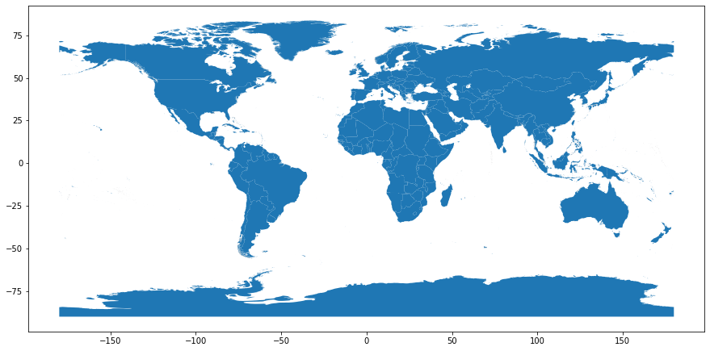

```python
world_map.plot();
```

This world map seems very stretched and Antarctica might not be of the outmost usefulness but we will still keep it, as some meteorite might have landed here.

First thing to do is then to link each coordinate with a country in the map: this process is called **reverse geocoding**. To use this, I created classes that act as wrapper for ogr ones using the [following code](https://github.com/che0/countries/blob/master/countries.py). These classes are in a local python file that we will now import.

```python
from modules import countries
```

To see how we will use this package, let's take the first line of our meteorite dataset as an example.

```python
first_meteorite = ds.iloc[0]
(lat, lon) = (first_meteorite[7], first_meteorite[8])
```

Now that we have retrieved it, let's check where it is positioned.

```python
c = countries.CountryChecker(country_file='datasets/geo-data/TM_WORLD_BORDERS-0.3.shp')
print(c.getCountry(countries.Point(lat, lon)).iso)
```

```
DE
```

Based on this process, we will alter our original dataset to provide it with a new column: country_code. To name it correctly, we will use the same name as in the GEOdataframe (i.e *ISO2*). For this intent, we will apply the following procedure.

```python
def retrieve_country_code(lat, lon):
    #Some coordinates are set to 0 due to misisng data, we will then insert None instead
    if (lat != 0 and lon != 0):
        #print(r'Treating ({},{})'.format(lat, lon))
        lat_str, lon_str = str(lat), str(lon)
        coord = lat_str+", "+lon_str
        location = c.getCountry(countries.Point(lat, lon))
        if location == None:
            return None
        else:
            return location.iso
    else:
        #print(r'Treating malicious coordinates')
        return None
```

```python
iso_col = []

for row in tqdm(ds.itertuples(index = True)):
    iso_col.append(retrieve_country_code(getattr(row,'reclat'), getattr(row,'reclong')))

ds['ISO2'] = pd.Series(iso_col)
```

```
45716it [21:18, 35.77it/s]
```

Let's now recheck our meteorite dataset:

```python
ds.head()
```

|  | name | id | nametype | recclass | mass | fall | year | reclat | reclong | GeoLocation | geometry | ISO2 |
| --- | --- | --- | --- | --- | --- | --- | --- | --- | --- | --- | --- | --- |
| 0 | Aachen | 1 | Valid | L5 | 21.0 | Fell | 1880.0 | 50.77500 | 6.08333 | (50.775000, 6.083330) | POINT (6.08333 50.77500) | DE |
| 1 | Aarhus | 2 | Valid | H6 | 720.0 | Fell | 1951.0 | 56.18333 | 10.23333 | (56.183330, 10.233330) | POINT (10.23333 56.18333) | DK |
| 2 | Abee | 6 | Valid | EH4 | 107000.0 | Fell | 1952.0 | 54.21667 | -113.00000 | (54.216670, -113.000000) | POINT (-113.00000 54.21667) | CA |
| 3 | Acapulco | 10 | Valid | Acapulcoite | 1914.0 | Fell | 1976.0 | 16.88333 | -99.90000 | (16.883330, -99.900000) | POINT (-99.90000 16.88333) | MX |
| 4 | Achiras | 370 | Valid | L6 | 780.0 | Fell | 1902.0 | -33.16667 | -64.95000 | (-33.166670, -64.950000) | POINT (-64.95000 -33.16667) | AR |

As we can see, it has been completed with an *"ISO2"* code column. This gives the country code of the found meteorite. We will now, for each country of our world map geopandas DataFrame, count the number of meteorites that were fallen and the number of meteorites that were found. We then add two new columns to the GeoPandas DataFrame and we will plot the map again, but in Choropleth mode this time.

```python
def count_iso_fell(iso_to_count):
    return len(ds[(ds["ISO2"] == iso_to_count) & (ds["fall"] == "Fell")])

def count_iso_found(iso_to_count):
    return len(ds[(ds["ISO2"] == iso_to_count) & (ds["fall"] == "Found")])
```

```python
world_map['fell'] = world_map['ISO2'].apply(count_iso_fell)
world_map['found'] = world_map['ISO2'].apply(count_iso_found)
```

#### Fell meteorites

Let's first analyze more in details which country has seen the most meteorites falling and check if it is linked with a high population density.

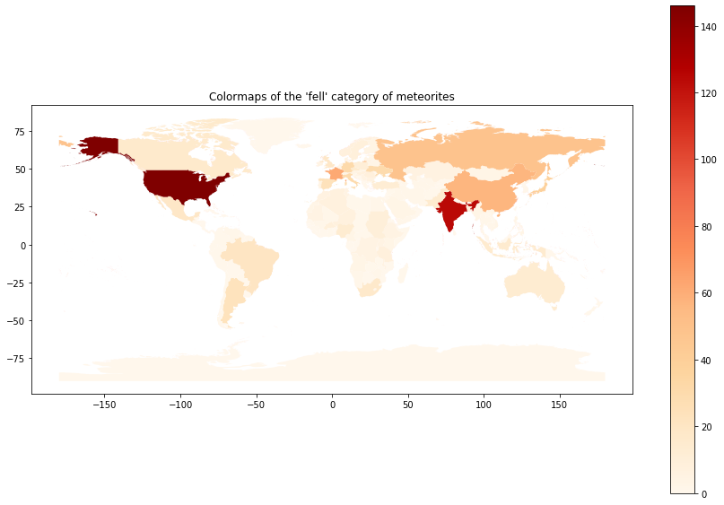

```python
fig, ax = plt.subplots(1, 1)
ax.set_title("Colormaps of the 'fell' category of meteorites")
world_map.plot(column='fell', ax=ax, legend=True, cmap='OrRd');
```

As we see on this map, most of the fell meteorites were, indeed, in populated countries and regions (the US, France, Russia, China, India..). This is very logical as the higher inhabitants number, the luckier a country is to spot falling meteorite.

To insure this, I will compare with a map of population density and do the ratio of spotted meteorite per inhabitants per squared-kilometer. For this intent, I will need to retrieve the density of population. For that, I will use the SQKM column of our world_map GeoPandas dataset and cross it with the population data of the Geopandas prebuilt "*naturalearth_lowres*".

```python
prebuilt_world = gpd.read_file(gpd.datasets.get_path('naturalearth_lowres'))
prebuilt_world.head()
```

|  | pop_est | continent | name | iso_a3 | gdp_md_est | geometry |
| --- | --- | --- | --- | --- | --- | --- |
| 0 | 920938 | Oceania | Fiji | FJI | 8374.0 | MULTIPOLYGON (((180.00000 -16.06713, 180.00000... |
| 1 | 53950935 | Africa | Tanzania | TZA | 150600.0 | POLYGON ((33.90371 -0.95000, 34.07262 -1.05982... |
| 2 | 603253 | Africa | W. Sahara | ESH | 906.5 | POLYGON ((-8.66559 27.65643, -8.66512 27.58948... |
| 3 | 35623680 | North America | Canada | CAN | 1674000.0 | MULTIPOLYGON (((-122.84000 49.00000, -122.9742... |
| 4 | 326625791 | North America | United States of America | USA | 18560000.0 | MULTIPOLYGON (((-122.84000 49.00000, -120.0000... |

```python
# we initialize the population density column to make sure that all country have at least a value (defaulting to 0)
world_map["pop_dens"] = np.zeros(world_map.shape[0]).astype(np.float16)
```

```python
# to help with merging, we rename the iso column and create a copy of the original dataset, with the renamed column.
copy_prebuilt = prebuilt_world.rename(columns={"iso_a3":"ISO3"})
```

```python
#this holds the result of the merge
result = pd.merge(world_map, copy_prebuilt[["ISO3","pop_est"]], how='outer', on=['ISO3'])
```

However, before calculating the density, we need to take care of countries such as Australia that are separated in different instance in this dataset (one per island). We need to set the SQKM to be the sum of all and distribute it evenly between the island.

```python
for iso in result["ISO3"].unique():
    samples = result[result["ISO3"] == iso]
    if (len(samples) > 1):
        total_sqkm = samples["SQKM"].sum()
        result.loc[result["ISO3"] == iso, "SQKM"] = total_sqkm
```

```python
# implements the formula to calculate a population density and pply it
def get_dens(country_pop, size):
    if (np.isnan(country_pop) == False and np.isnan(size) == False and country_pop > 0 and size > 0):
        return math.ceil(country_pop/size)
    else:
        return 0

result["pop_dens"] = result.apply(lambda row: get_dens(row["pop_est"],row["SQKM"]), axis=1)
```

Now that we have our population density data loaded in our dataset, we will just use it to divide the number of fallen meteorites and see which country tends to catch the most meteorite par inhabitant per squared kilometer.

```python
def divide_fallen_by_popdens(fallen, pop_dens):
    if (np.isnan(pop_dens) == False and np.isnan(fallen) == False and pop_dens != 0):
        return fallen/pop_dens
    else:
        return 0

result["fallen_by_pop_dens"] = result.apply(lambda row: divide_fallen_by_popdens(row["fell"], row["pop_dens"]), axis=1)
```

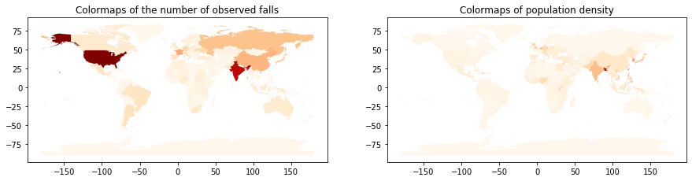

```python
f, (ax1, ax2) = plt.subplots(1, 2)
ax1.set_title("Colormaps of the number of observed falls")
ax2.set_title("Colormaps of population density")
world_map.plot(column='fell', ax=ax1, cmap='OrRd');
result.plot(column='pop_dens', ax=ax2, cmap='OrRd');
```

We can easily observe that similar countries stand out from both of these plots (India, Chine, Western Europe). This indicates that the density of population is an important factors when it comes to seeing falling stars.

One major exception here is the US, where its population is centered around main cities, leaving a lot of empty countryside (as we can see in this image).

[figure not shown]

US Population density (source: [link](http://ecpmlangues.u-strasbg.fr/))

The highest position of the US is notably due to the presence of Nasa as a government agency: this enhances their abilities in tracking meteorites from the stars and being able to see their falls in an easier way and doing so, if not for entertainment purposes, at least for scientific ones. These are the main motives of the US.

#### Found meteorites

Let's now see the main countries of the found meteorite. As seen before in the Feature Analysis part, Antarctica should play an important role here.

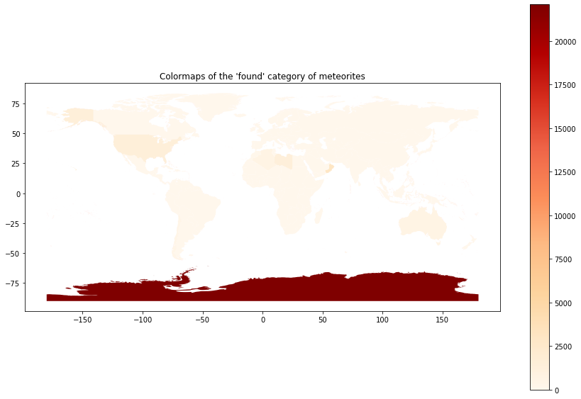

```python
fig_b, ax_b = plt.subplots(1, 1)
ax_b.set_title("Colormaps of the 'found' category of meteorites")
world_map.plot(column='found', ax=ax_b, legend=True, cmap="OrRd");
```

As seen here, Antarctica has, without any competition, the highest amount of found meteorites. All of them are "*found*" and not seen as there is not that many people in Antarctica actually being able to see this. As we could think, there must be a reason why so many meteorites are found in Antarctica.

#### Analysis conclusion

First thought that could come in mind is that more meteorites are actually falling in Antarctica. However, there is nothing indicating that meteorites tend to fall in Antarctica more often than anywhere else. What the data say is that it is more common to find a meteorite in Antarctica and this for three main reasons:

- Antarctica is a snow-white land where any piece of brown-ish material will easily be spotted by anyone, including satellite or aerial imagery.
- The date of discovery of meteorite differs from the date of fall. Antarctica has existed for such a long time that there exist a very long timespan of eventual meteorite falls.
- Linked to the last fact, Antarctica is cold. Ice-like cold. These conditions are perfect to preserve the quality of the meteorites and to protect them from Earth weather.

This last fact is then leading us to a new interrogation:

> Where do relict meteorites most often come from and what characteristics do they have ?

We will see this in the following part.

### Where do relict meteorites most often come from and what characteristics do they have ?

As we have seen when analyzing the "*nametype*" feature of our meteorite dataset, the vast majority of the listed meteorites are intact as they may either have been found soon after they reached Earth (mostly, we are talking about "*fell*" type of meteorite) or they have been very well preserved in the ice of Antarctica. But what about the relict meteorite ? How could they have been found and classified ?

To know more about this, we will link this feature to the others available.

```python
ds_relict = ds[ds["nametype"] == "Relict"]
```

```python
def count_iso_relict(iso_to_count):
    return len(ds_relict[(ds_relict["ISO2"] == iso_to_count)])

world_map["relict_count"] = world_map["ISO2"].apply(count_iso_relict)
```

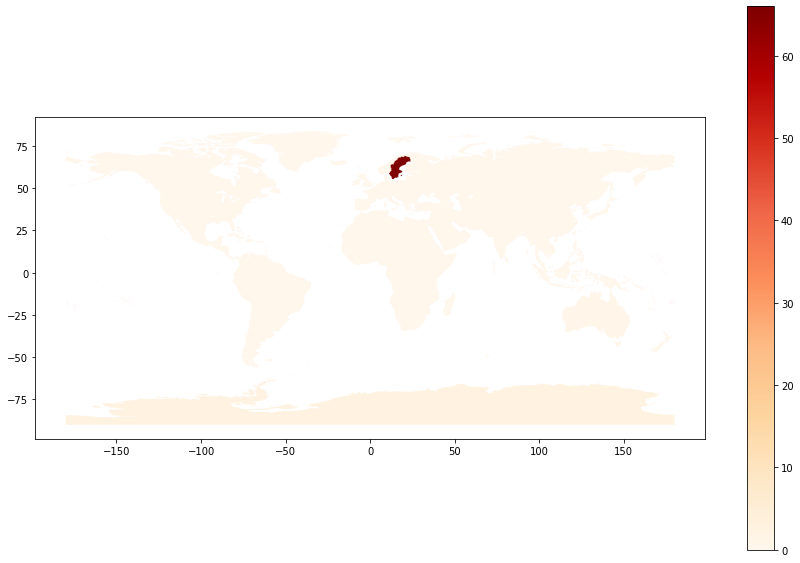

```python
world_map.plot(column="relict_count", legend=True, cmap="OrRd")
```

As we observe here, there seem to be only Sweden where relict meteorites are found. This country did not stand out as having discovered that many meteorites. But where exactly in Sweden are they positioned ? First, let's see if other countries that are not easy to catch here may host a few relict meteorites.

```python
non_null_relict = world_map[world_map["relict_count"] > 0]
```

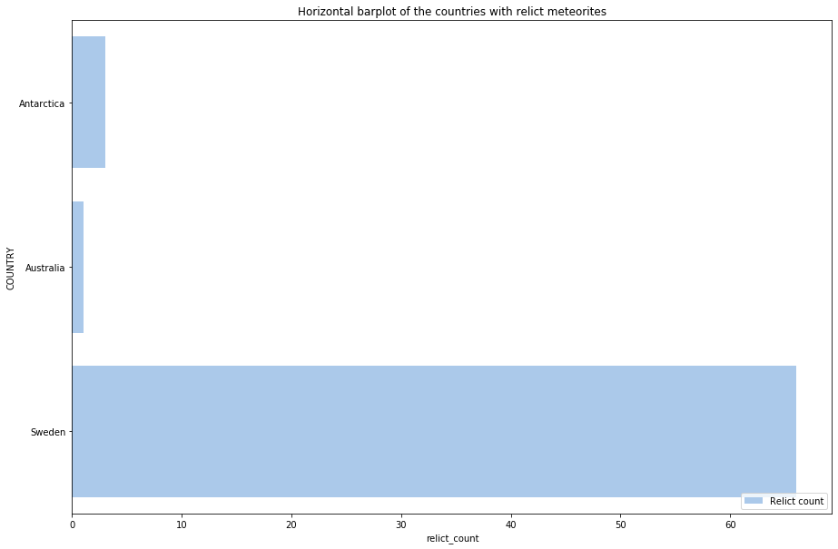

```python
f, ax = plt.subplots()

sns.set_color_codes("pastel")
non_null_relict_barplot = sns.barplot(
    x="relict_count", y="COUNTRY", label="Relict count", data=non_null_relict, color="b")

# Add a legend and informative axis label
ax.legend(ncol=2, loc="lower right", frameon=True)

non_null_relict_barplot.set_title("Horizontal barplot of the countries with relict meteorites")
non_null_relict_barplot;
```

As we can here see, both Australia and Antarctica have a few relict meteorites (1 for Australia, 3 for Antarctica). Let's now focus on Sweden.

To think about this part of the dataset, we should think about how it could differ from the rest of the meteorites. In other terms, what has changed perfectly untouched meteorites to relict ones. Their place of discovery, their date of fall or even their recclass may be hints on directions to take.

#### Where do we find relict meteorites ?

```python
sweden_relict = ds_relict[ds_relict["ISO2"]=="SE"]

m3 = folium.Map(
    #layers=(basemap_to_tiles(basemaps.NASAGIBS.ModisTerraTrueColorCR, "2017-04-08"), ),
    location=[62.6431513,16.2680932],
    zoom_start=4
)

for pos_as_str in sweden_relict["GeoLocation"].unique():
    try:
        pos = eval(pos_as_str)
        #print(r"Position: {}".format(pos))
        folium.Marker(list(pos[0], pos[1]), popup=pos_as_str).add_to(m3)
    except:
        print("Invalid position")

print("All meteorite unique positions: {}".format(sweden_relict["GeoLocation"].unique()))
m3
```

```
Invalid position
Invalid position
Invalid position
All meteorite unique positions: ['(63.116670, 14.283330)' '(58.383330, 13.800000)'
 '(58.583330, 13.433330)']
```

[interactive chart not shown]

When exporting this dataframe to an HTML table, we obtain the following:

|  | name | id | nametype | recclass | mass | fall | year | reclat | reclong | GeoLocation | ISO2 |
| --- | --- | --- | --- | --- | --- | --- | --- | --- | --- | --- | --- |
| 5182 | Brunflo | 5157 | Relict | Relict H | NaN | Found | 1980.0 | 63.11667 | 14.28333 | (63.116670, 14.283330) | SE |
| 15944 | Gullhögen 001 | 44889 | Relict | Relict OC | NaN | Found | 2000.0 | 58.38333 | 13.80000 | (58.383330, 13.800000) | SE |
| 31013 | Osterplana | 18038 | Relict | Relict OC | NaN | Found | 1987.0 | 58.58333 | 13.43333 | (58.583330, 13.433330) | SE |
| 31014 | Österplana 002 | 44802 | Relict | Relict OC | NaN | Found | 1993.0 | 58.58333 | 13.43333 | (58.583330, 13.433330) | SE |
| 31015 | Österplana 003 | 44803 | Relict | Relict OC | NaN | Found | 1993.0 | 58.58333 | 13.43333 | (58.583330, 13.433330) | SE |
| 31016 | Österplana 004 | 44804 | Relict | Relict OC | NaN | Found | 1994.0 | 58.58333 | 13.43333 | (58.583330, 13.433330) | SE |
| 31017 | Österplana 005 | 44805 | Relict | Relict OC | NaN | Found | 1990.0 | 58.58333 | 13.43333 | (58.583330, 13.433330) | SE |
| 31018 | Österplana 006 | 44806 | Relict | Relict OC | NaN | Found | NaN | 58.58333 | 13.43333 | (58.583330, 13.433330) | SE |
| 31019 | Österplana 007 | 44807 | Relict | Relict OC | NaN | Found | 1993.0 | 58.58333 | 13.43333 | (58.583330, 13.433330) | SE |
| 31020 | Österplana 008 | 44808 | Relict | Relict OC | NaN | Found | 1995.0 | 58.58333 | 13.43333 | (58.583330, 13.433330) | SE |
| 31021 | Österplana 009 | 44809 | Relict | Relict OC | NaN | Found | 1996.0 | 58.58333 | 13.43333 | (58.583330, 13.433330) | SE |
| 31022 | Österplana 010 | 44810 | Relict | Relict OC | NaN | Found | 1995.0 | 58.58333 | 13.43333 | (58.583330, 13.433330) | SE |
| 31023 | Österplana 011 | 44811 | Relict | Relict OC | NaN | Found | 1997.0 | 58.58333 | 13.43333 | (58.583330, 13.433330) | SE |
| 31024 | Österplana 012 | 44812 | Relict | Relict OC | NaN | Found | 1996.0 | 58.58333 | 13.43333 | (58.583330, 13.433330) | SE |
| 31025 | Österplana 013 | 44813 | Relict | Relict OC | NaN | Found | 1996.0 | 58.58333 | 13.43333 | (58.583330, 13.433330) | SE |
| 31026 | Österplana 014 | 44814 | Relict | Relict OC | NaN | Found | 1996.0 | 58.58333 | 13.43333 | (58.583330, 13.433330) | SE |
| 31027 | Österplana 015 | 44815 | Relict | Relict OC | NaN | Found | 1996.0 | 58.58333 | 13.43333 | (58.583330, 13.433330) | SE |
| 31028 | Österplana 016 | 44816 | Relict | Relict OC | NaN | Found | 1996.0 | 58.58333 | 13.43333 | (58.583330, 13.433330) | SE |
| 31029 | Österplana 017 | 44817 | Relict | Relict OC | NaN | Found | 1997.0 | 58.58333 | 13.43333 | (58.583330, 13.433330) | SE |
| 31030 | Österplana 018 | 44818 | Relict | Relict OC | NaN | Found | 1996.0 | 58.58333 | 13.43333 | (58.583330, 13.433330) | SE |
| 31031 | Österplana 019 | 44819 | Relict | Relict OC | NaN | Found | 1997.0 | 58.58333 | 13.43333 | (58.583330, 13.433330) | SE |
| 31032 | Österplana 020 | 44820 | Relict | Relict OC | NaN | Found | 1997.0 | 58.58333 | 13.43333 | (58.583330, 13.433330) | SE |
| 31033 | Österplana 021 | 44821 | Relict | Relict OC | NaN | Found | 1997.0 | 58.58333 | 13.43333 | (58.583330, 13.433330) | SE |
| 31034 | Österplana 022 | 44822 | Relict | Relict OC | NaN | Found | 1999.0 | 58.58333 | 13.43333 | (58.583330, 13.433330) | SE |
| 31035 | Österplana 023 | 44823 | Relict | Relict OC | NaN | Found | 1999.0 | 58.58333 | 13.43333 | (58.583330, 13.433330) | SE |
| 31036 | Österplana 024 | 44824 | Relict | Relict OC | NaN | Found | 1999.0 | 58.58333 | 13.43333 | (58.583330, 13.433330) | SE |
| 31037 | Österplana 025 | 44825 | Relict | Relict OC | NaN | Found | 2000.0 | 58.58333 | 13.43333 | (58.583330, 13.433330) | SE |
| 31038 | Österplana 026 | 44826 | Relict | Relict OC | NaN | Found | 2000.0 | 58.58333 | 13.43333 | (58.583330, 13.433330) | SE |
| 31039 | Österplana 027 | 44827 | Relict | Relict OC | NaN | Found | 2000.0 | 58.58333 | 13.43333 | (58.583330, 13.433330) | SE |
| 31040 | Österplana 028 | 44828 | Relict | Relict OC | NaN | Found | 2000.0 | 58.58333 | 13.43333 | (58.583330, 13.433330) | SE |
| 31041 | Österplana 029 | 44829 | Relict | Relict OC | NaN | Found | 1998.0 | 58.58333 | 13.43333 | (58.583330, 13.433330) | SE |
| 31042 | Österplana 030 | 44830 | Relict | Relict OC | NaN | Found | 1994.0 | 58.58333 | 13.43333 | (58.583330, 13.433330) | SE |
| 31043 | Österplana 031 | 44831 | Relict | Relict OC | NaN | Found | 1998.0 | 58.58333 | 13.43333 | (58.583330, 13.433330) | SE |
| 31044 | Österplana 032 | 44832 | Relict | Relict OC | NaN | Found | 2000.0 | 58.58333 | 13.43333 | (58.583330, 13.433330) | SE |
| 31045 | Österplana 033 | 44833 | Relict | Relict OC | NaN | Found | 2000.0 | 58.58333 | 13.43333 | (58.583330, 13.433330) | SE |
| 31046 | Österplana 034 | 44834 | Relict | Relict OC | NaN | Found | 1998.0 | 58.58333 | 13.43333 | (58.583330, 13.433330) | SE |
| 31047 | Österplana 035 | 44835 | Relict | Relict OC | NaN | Found | 1996.0 | 58.58333 | 13.43333 | (58.583330, 13.433330) | SE |
| 31048 | Österplana 036 | 44836 | Relict | Relict OC | NaN | Found | 1996.0 | 58.58333 | 13.43333 | (58.583330, 13.433330) | SE |
| 31049 | Österplana 037 | 44837 | Relict | Relict OC | NaN | Found | 1998.0 | 58.58333 | 13.43333 | (58.583330, 13.433330) | SE |
| 31050 | Österplana 038 | 44838 | Relict | Relict OC | NaN | Found | 1999.0 | 58.58333 | 13.43333 | (58.583330, 13.433330) | SE |
| 31051 | Österplana 039 | 44839 | Relict | Relict OC | NaN | Found | 2000.0 | 58.58333 | 13.43333 | (58.583330, 13.433330) | SE |
| 31052 | Österplana 040 | 44840 | Relict | Relict OC | NaN | Found | 2000.0 | 58.58333 | 13.43333 | (58.583330, 13.433330) | SE |
| 31053 | Österplana 041 | 44841 | Relict | Relict OC | NaN | Found | 1996.0 | 58.58333 | 13.43333 | (58.583330, 13.433330) | SE |
| 31054 | Österplana 042 | 44842 | Relict | Relict OC | NaN | Found | 2000.0 | 58.58333 | 13.43333 | (58.583330, 13.433330) | SE |
| 31055 | Österplana 043 | 44843 | Relict | Relict OC | NaN | Found | 2002.0 | 58.58333 | 13.43333 | (58.583330, 13.433330) | SE |
| 31056 | Österplana 044 | 44844 | Relict | Relict OC | NaN | Found | 2002.0 | 58.58333 | 13.43333 | (58.583330, 13.433330) | SE |
| 31057 | Österplana 045 | 44845 | Relict | Relict OC | NaN | Found | 2002.0 | 58.58333 | 13.43333 | (58.583330, 13.433330) | SE |
| 31058 | Österplana 046 | 44846 | Relict | Relict OC | NaN | Found | 2002.0 | 58.58333 | 13.43333 | (58.583330, 13.433330) | SE |
| 31059 | Österplana 047 | 44847 | Relict | Relict OC | NaN | Found | 2002.0 | 58.58333 | 13.43333 | (58.583330, 13.433330) | SE |
| 31060 | Österplana 048 | 56147 | Relict | Relict OC | 0.0 | Found | 2004.0 | 58.58333 | 13.43333 | (58.583330, 13.433330) | SE |
| 31061 | Österplana 049 | 56148 | Relict | Relict OC | 0.0 | Found | 2012.0 | 58.58333 | 13.43333 | (58.583330, 13.433330) | SE |
| 31062 | Österplana 050 | 56149 | Relict | Relict OC | 0.0 | Found | 2003.0 | 58.58333 | 13.43333 | (58.583330, 13.433330) | SE |
| 31063 | Österplana 051 | 56150 | Relict | Relict OC | 0.0 | Found | 2006.0 | 58.58333 | 13.43333 | (58.583330, 13.433330) | SE |
| 31064 | Österplana 052 | 56151 | Relict | Relict OC | 0.0 | Found | 2006.0 | 58.58333 | 13.43333 | (58.583330, 13.433330) | SE |
| 31065 | Österplana 053 | 56152 | Relict | Relict OC | 0.0 | Found | 2002.0 | 58.58333 | 13.43333 | (58.583330, 13.433330) | SE |
| 31066 | Österplana 054 | 56153 | Relict | Relict OC | 0.0 | Found | 2005.0 | 58.58333 | 13.43333 | (58.583330, 13.433330) | SE |
| 31067 | Österplana 055 | 56154 | Relict | Relict OC | 0.0 | Found | 2008.0 | 58.58333 | 13.43333 | (58.583330, 13.433330) | SE |
| 31068 | Österplana 056 | 56155 | Relict | Relict OC | 0.0 | Found | 2008.0 | 58.58333 | 13.43333 | (58.583330, 13.433330) | SE |
| 31069 | Österplana 057 | 56156 | Relict | Relict OC | 0.0 | Found | 2009.0 | 58.58333 | 13.43333 | (58.583330, 13.433330) | SE |
| 31070 | Österplana 058 | 56157 | Relict | Relict OC | 0.0 | Found | 2009.0 | 58.58333 | 13.43333 | (58.583330, 13.433330) | SE |
| 31071 | Österplana 059 | 56158 | Relict | Relict OC | 0.0 | Found | 2009.0 | 58.58333 | 13.43333 | (58.583330, 13.433330) | SE |
| 31072 | Österplana 060 | 56159 | Relict | Relict OC | 0.0 | Found | 2009.0 | 58.58333 | 13.43333 | (58.583330, 13.433330) | SE |
| 31073 | Österplana 061 | 56160 | Relict | Relict OC | 0.0 | Found | 2009.0 | 58.58333 | 13.43333 | (58.583330, 13.433330) | SE |
| 31074 | Österplana 062 | 56161 | Relict | Relict OC | 0.0 | Found | 2010.0 | 58.58333 | 13.43333 | (58.583330, 13.433330) | SE |
| 31075 | Österplana 063 | 56162 | Relict | Relict OC | 0.0 | Found | 2010.0 | 58.58333 | 13.43333 | (58.583330, 13.433330) | SE |
| 31076 | Österplana 064 | 56163 | Relict | Relict OC | 0.0 | Found | 2011.0 | 58.58333 | 13.43333 | (58.583330, 13.433330) | SE |

We see here that most of them are called "*Österplana*" and are of recclass "*Relict OC*" which stands for "relict ordinary chondrite". Two other examples are:

- Gullhögen (Relict OC)
- Brunflo (Relict H, which means that it originated as an H group ordinary chondrite)

After research, all Österplana were meteorites found in the same quarry, the quarry of Thorsberg. One very important meteorite, missing in the relict part of the dataset is the Österplana 065, which was found at the same spot as other meteorites but was radically different from them in term of composition: When all the other meteorites were chondrites of the same type, this n°065 was closer to winoaïtes and primitives achondrites. This meant that this meteorite did not come from the same bigger meteor. One theory states that this meteorite may come from the meteor that crashed onto the second meteor, from which come from all the other *Österplana* meteorites.

Does our global dataset contain such meteorite ?

```python
print("Does our dataset contain such meteorite ? {}".format("Österplana 065" in ds["name"]))
```

```
Does our dataset contain such meteorite ? False
```

### What characterizes unclassified stones ?

Another question that we raised was about the unclassified stones. Do they have any uncommon characteristics ? Let's find out !

```python
ds_uncl = ds[ds["recclass"] == "Stone-uncl"]
```

Let's first plot a map of all our unclassified meteorite to see any pattern.

```python
m4 = folium.Map(
    zoom_start=1,
    tiles='Stamen Terrain')

for pos_as_str in ds_uncl["GeoLocation"].unique():
    try:
        pos = eval(pos_as_str)
        #print(r"Position: {}".format(pos))
        folium.Marker(list(pos), title=pos_as_str).add_to(m4)
    except:
        print("Invalid position")

m4
```

```
Invalid position
```

[interactive chart not shown]

As we can here see, a lot of unclassified stones have been found in populated area such as Europe or Eastern Asia. But when were they found ? And where they seen falling ? We will check this use a very common scatter plot.

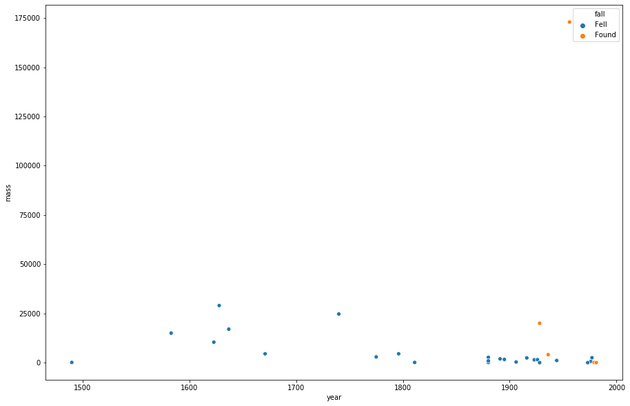

```python
sns.scatterplot(x="year", y="mass", data=ds_uncl, hue="fall")
```

As we can tell here, the main majority of the unclassified stones have been seen falling, which quite suprising as it denotes with the rest of the dataset. Reports of said "fell" meteorites go back to before 1500 and up to the late 80s/90s. Two meteorites stand out particularly from this subdataset:

- The oldest "fell" one
- The heaviest "found" one

We will now analyze both of them to try pulling out as much infomartion as possible.

#### Oldest unclassified stone

```python
oldest_stone = ds_uncl[ds_uncl["year"] < 1500]
oldest_stone
```

|  | name | id | nametype | recclass | mass | fall | year | reclat | reclong | GeoLocation | geometry | ISO2 |
| --- | --- | --- | --- | --- | --- | --- | --- | --- | --- | --- | --- | --- |
| 678 | Narni | 16914 | Valid | Stone-uncl | NaN | Fell | 920.0 | 42.51667 | 12.51667 | (42.516670, 12.516670) | POINT (12.51667 42.51667) | IT |
| 852 | Rivolta de Bassi | 22614 | Valid | Stone-uncl | 103.3 | Fell | 1490.0 | 45.48333 | 9.51667 | (45.483330, 9.516670) | POINT (9.51667 45.48333) | IT |
| 1040 | Valdinoce | 24146 | Valid | Stone-uncl | NaN | Fell | 1495.0 | 44.06667 | 12.10000 | (44.066670, 12.100000) | POINT (12.10000 44.06667) | IT |

When searching for the oldest meteorite, it happens to show two other meteorite that were not plotted, due to Nan values of the mass attribute. All of these were found in Italy.

```python
oldest_stone = oldest_stone[oldest_stone["name"] == "Rivolta de Bassi"]

pos = eval(oldest_stone["GeoLocation"].values[0])

m_old = folium.Map(
    #layers=(basemap_to_tiles(basemaps.NASAGIBS.ModisTerraTrueColorCR, "2017-04-08"), ),
    location=list(pos),
    zoom_start=10
)

folium.Marker(list(pos), popup=str(pos)).add_to(m_old)

m_old
```

[interactive chart not shown]

This meteorite appears to have been found near by Milano, in the year 1490. When searching for it on different ressources, we obtain the following information:

> *A stone the size of a man's head, light grey with a "burnt" surface, was seen to fall near Crema, E.F.F. Chladni, Die Feuer-Meteore. This was clearly a true meteorite. The co-ordinates given are those of Rivolta D'Adda, the modem name of Rivolta de Bami.* [source](https://books.google.co.uk/books?id=K4YDHZP4D50C&pg=PA6&hl=fr#v=onepage&q&f=false)

We saw earlier that other unclassified meteorites were found in Italy. Where are they and how many of them is there ?

```python
ds_uncl_it = ds_uncl[ds_uncl["ISO2"] == "IT"]

m_it = folium.Map(
    #layers=(basemap_to_tiles(basemaps.NASAGIBS.ModisTerraTrueColorCR, "2017-04-08"), ),
    location=list(eval(oldest_stone["GeoLocation"].values[0])),
    zoom_start=5,
    tiles="Stamen Terrain")

for pos_as_str in ds_uncl_it["GeoLocation"].unique():
    try:
        pos = eval(pos_as_str)
        #print(r"Position: {}".format(pos))
        folium.Marker(list(pos), popup=pos_as_str).add_to(m_it)
    except:
        print("Invalid position")

m_it
```

[interactive chart not shown]

As we can here see, most of the stones were spread out in Italia. I highly doubt that they are linked with each other.

#### Heaviest unclassified stone

With a wapping of 175000gr (175kg), the heaviest found stone that is yet to be classified is the next stop on our list of meteorites to analyze.

```python
heaviest_stone_uncl = ds_uncl[ds_uncl["mass"]>170000]
heaviest_stone_uncl
```

|  | name | id | nametype | recclass | mass | fall | year | reclat | reclong | GeoLocation | geometry | ISO2 |
| --- | --- | --- | --- | --- | --- | --- | --- | --- | --- | --- | --- | --- |
| 37798 | Tamir-Tsetserleg | 23799 | Valid | Stone-uncl | 173000.0 | Found | 1956.0 | 47.45 | 101.47917 | (47.450000, 101.479170) | POINT (101.47917 47.45000) | MN |

According to these information, the stone was found in Mongolia. More precisely in Tsetserleg, a region with a lot of hilly and mountainous areas. According to its GeoLocation information, our stone was found here:

```python
heaviest_stone_uncl_pos = heaviest_stone_uncl["GeoLocation"].values[0]

m_mn = folium.Map(
    location=list(eval(heaviest_stone_uncl_pos)),
    zoom_start=9,
    tiles='Stamen Terrain'
)

folium.Marker(list(eval(heaviest_stone_uncl_pos)), popup=heaviest_stone_uncl_pos).add_to(m_mn)

m_mn
```

[interactive chart not shown]

As we can here see, the meteorite appears to have been found in the middle of mountains, making its finding even more spectacular. While making research about the following meteorite, an even more suprising event was related:

[figure not shown]

This very impressive meteor was the largest known natural object to have entered Earth's atmosphere since the 1908 Tunguska event. After months of evaluation, it had been determined to come from the LL chondrite group, which we already saw as being very common amongst meteorites. When arriving to Earth, splitting in a lot of smaller meteors, this 10k tons meteorite hit not less than 7200 buildings including 6040 apartment blocks and hundreds of schools. This shocking event, striking without any warning, was a concretet proof that Earth wwas and STILL IS vulnerable to meteor.

## Conclusion

As we have seen, we received plenty of meteors of all sizes, at all ages and from all types, arriving at every corner of the world. Some places were more prone to finding meteors (e.g Antarctica) but that was not because of higher chances of receiving a meteorite. based on these observations, we can clearly state that no one is safe from meteorite falls and an worldwide detection system could be a very good way to prevent the event of the 2010 Chelyabinsk meteor.

## Credit

This dataset was download on Kaggle at the following [link](https://www.kaggle.com/nasa/meteorite-landings).

This dataset was made using NASA's Data Portal, and is based on The Meteoritical Society's Meteoritical Bulletin Database (this latter database provides additional information such as meteorite images, links to primary sources, etc.).

More details about meteorites have been found in the following websites:

- [Wikipedia](https://en.wikipedia.org/wiki/Meteorite)
- [Answers.com](https://www.answers.com/Q/Why_have_so_many_meteorites_been_found_in_Antarctica)
- [Fredzone.org](http://www.fredzone.org/une-meteorite-unique-en-son-genre-a-ete-retrouvee-en-suede-665)
- [Wikipedia](https://en.wikipedia.org/wiki/Chelyabinsk_meteor)